# Simulation study

In this simulation study, we aim to see whether AMIS is capable of recovering the true parameter values used to simulate data.

### Data generating process

We assumed that the number of worms $X$ per host has negative binomial distribution NB($W$,$k$), where $W$ is the mean number of worms and $k$ the dispersion parameter describing the degree of clumping of parasites. The probability mass function is given by
$$\begin{equation}
\text{Pr}(X=x) = \frac{\Gamma(x+k)}{\Gamma(k)x!}
\left(\frac{k}{k+W}\right)^k \left(\frac{W}{k+W}\right)^x, \quad
x=0,1,2,\dots.
\end{equation}$$

As such, the prevalence is given by the probability of observing worms:

$$\begin{align}
P &= 1 - \text{Pr}\big(X=0 \ \vert \ W, k \big)\\
&= 1 - \left( 1 + \frac{W}{k} \right)^{-k}.
\end{align}$$

We assumed each location $l$ has $n_l$ hosts, so that the number of worms per host in location $l$ at time $t$ was simulated by
$$X_{i,l,t} \sim \text{NB}(W_l, k_l), \quad i=1,\dots,n_l,$$
so that the prevalence in location $l$ at time $t$ is given by
$$P_{l,t} = \frac{1}{n_l}\sum_{i=1}^{n_l}\text{I}_{\{X_{i,l,t}>0\}}.$$

### Loading packages

```r
library("AMISforInfectiousDiseases")
library("ggplot2")
library("patchwork")
library("viridis")
library("dplyr")
```

### Generating spatially-varying mean number of worms

```r
lon <- seq(-4, 4, length.out=50)
lat <- seq(-2, 2, length.out=50)
simData <- expand.grid(lon=lon, lat=lat, W=NA, k=NA, expectedPrev=NA)
L <- nrow(simData) # number of locations
Sigma <- diag(2)
Sigma[1,2] <- Sigma[2,1] <- 0.7
for(l in 1:L){
  pos <- as.numeric(simData[l,c("lon","lat")])
  W <- 5*exp(-0.5*c(pos%*%Sigma%*%pos))
  k <- 0.4
  simData$W[l] <- W
  simData$k[l] <- k
  simData$expectedPrev[l] <- 1 - (1 + W/k)^(-k)
}
```

Below we can see how the mean number of worms and the corresponding prevalence (at the equilibrium distribution) vary over space.

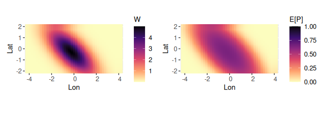

```r
simData_sf <- sf::st_as_sf(simData %>% dplyr::select(lon,lat,W,k,expectedPrev),
                           coords=c("lon","lat"))
th <- theme(axis.text=element_text(size=10),
            legend.text=element_text(size=10))
plots_true_data <- vector(mode = "list", length = 2)
plots_true_data[[1]] <- ggplot(data=simData_sf) +
  geom_sf(aes(colour=W),shape=15,size=5) + xlab("Lon") + ylab("Lat") + th +
  scale_colour_gradientn(colours=rev(viridis::magma(6)), name="W", na.value="grey100")
plots_true_data[[2]] <- ggplot(data=simData_sf) +
  geom_sf(aes(colour=expectedPrev),shape=15,size=5) +
  xlab("Lon") + ylab("Lat") + th +
  scale_colour_gradientn(colours=rev(viridis::magma(6)),
                         name="E[P]", na.value="grey100",
                         limits=c(0,1))
wrap_plots(plots_true_data, guides = 'keep', ncol = 2)
```

### Generating map samples for multiple time points

```r
set.seed(1)
n_hosts <- 500  # number of hosts per location
M <- 100        # number of statistical map samples per location
n_tims <- 3     # number of time points
prevalence_map <- vector(mode = "list", length = n_tims)
for(t in 1:n_tims){
  prevs_t <- matrix(NA,L,M)
  for (l in 1:L) {
    for(m in 1:M){
      W <- simData$W[l]
      k <- simData$k[l]
      num_worms_l <- rnbinom(n=n_hosts, mu=W, size=k)
      prevs_t[l,m] <- sum(num_worms_l>0)/n_hosts
    }
  }
  prevalence_map[[t]]$data <- prevs_t
}
```

### Choosing the transmission model function

```r
transmission_model <- function(seeds, params, n_tims){
  n_samples <- nrow(params)
  p <- matrix(NA, nrow=n_samples, ncol=n_tims)
  for(tt in 1:n_tims){
    for (i in 1:n_samples){
      W <- params[i,1]
      k <- params[i,2]
      p[i,tt] <- 1-(1+W/k)^(-k)
    }
  }
  return(p)
}
```

### Choosing the prior distributions and AMIS control parameters

```r
# Prior distribution for the model parameters
rprior <- function(n) {
  params <- matrix(NA, n, 2)
  colnames(params) <- c("W", "k")
  params[,1] <- rexp(n=n, rate=lambda_W)
  params[,2] <- rexp(n=n, rate=lambda_k)
  return(params)
}
dprior <- function(x, log=FALSE) {
  if (log) {
    return(dexp(x=x[1], rate=lambda_W, log=T) + dexp(x=x[2], rate=lambda_k, log=T))
  } else {
    return(dexp(x=x[1], rate=lambda_W) * dexp(x=x[2], rate=lambda_k))
  }
}
prior <- list(rprior=rprior,dprior=dprior)

amis_params <- AMISforInfectiousDiseases:::default_amis_params()
amis_params$n_samples <- 500
amis_params$target_ess <- 10000
amis_params$max_iters <- 10
amis_params$delta <- 0.1
```

### Running AMIS

In the lines below, we fit AMIS to the statistical maps by using different prior specifications for $k$, namely $\text{Exp}(\lambda_k), \ \lambda_k \in \{0.1, 0.3, 1\}$.

```r
lambda_W <- 1/3
lambda_k_values <- c(0.1,0.3,1)
num_lambda_k <- length(lambda_k_values)
outList <- vector("list", num_lambda_k)
i <- 1
for(lambda_k in lambda_k_values){
  outList[[i]] <- amis(prevalence_map, transmission_model, prior, amis_params, seed=1)
  i <- i + 1
}
```

### Looking at posterior distribution of parameters

We can look at the posterior distribution for $k$ at some particular location, e.g. the location with the largest mean number of worms:

```r
loc <- which.max(simData$W)
xlimW <- c(0,10)
Wvals <- seq(xlimW[1],xlimW[2],len=100)
W_prior_dens <- dexp(Wvals, rate=lambda_W)
xlimk <- c(0,10)
kvals <- seq(xlimk[1],xlimk[2],len=100)
i <- 1
plots_k <- vector(mode = "list", length = num_lambda_k)
plots_W <- vector(mode = "list", length = num_lambda_k)
for(lambda_k in lambda_k_values){
  k_prior_dens <- dexp(kvals, rate=lambda_k)
  out <- outList[[i]]
  # plotting W
  plot(out, what = "W", type="hist", breaks=50, xlim=xlimW,
         locations=loc, main=NA)
  lines(Wvals, W_prior_dens, col="blue", lwd=2, lty=2)
    abline(v = simData$W[loc], col="red", lwd=2, lty=2)
    plots_W[[i]] <- recordPlot()
  # plotting k
    plot(out, what = "k", type="hist", breaks=100, xlim=xlimk,
       locations=loc, main=bquote(lambda[k]*"="*.(lambda_k)))
  lines(kvals, k_prior_dens, col="blue", lwd=2, lty=2)
    abline(v = simData$k[loc], col="red", lwd=2, lty=2)
    plots_k[[i]] <- recordPlot()
    i <- i + 1
}
```

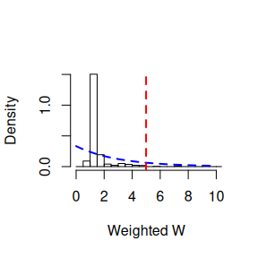

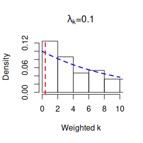

```r
plots_W[[1]]
plots_k[[1]]
```

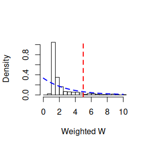

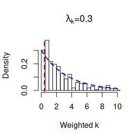

```r
plots_W[[2]]
plots_k[[2]]
```

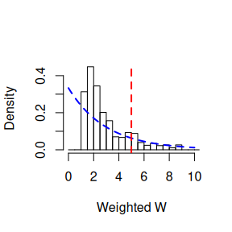

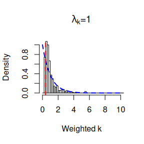

```r
plots_W[[3]]
plots_k[[3]]
```

We can clearly see that the posterior distribution of $k$ is largely determined by the prior, and that the existence of multiple time points did not help the recovery of the true parameter values.

### Introducing intervention

Now, we assume that an intervention (reduction of the mean number of worms by $70\%$) occurs at time $t=2$ and still has effect at $t=3$.

```r
for(t in 2:3){
  prevs_t <- matrix(NA,L,M)
  for (l in 1:L) {
    for(m in 1:M){
      W <- simData$W[l] * 0.3
      k <- simData$k[l]
      num_worms_l <- rnbinom(n=n_hosts, mu=W, size=k)
      prevs_t[l,m] <- sum(num_worms_l>0)/n_hosts
    }
  }
  prevalence_map[[t]]$data <- prevs_t
}
```

The intervention is known and is also taken into account in the transmission model:

```r
transmission_model <- function(seeds, params, n_tims){
  n_samples <- nrow(params)
  p <- matrix(NA, nrow=n_samples, ncol=n_tims)
  for(t in 1:n_tims){
    for (i in 1:n_samples){
      if(t==1){
        W <- params[i,1]
      }else{
        W <- params[i,1] * 0.3
      }
      k <- params[i,2]
      p[i,t] <- 1-(1+W/k)^(-k)
    }
  }
  return(p)
}
```

We then fit AMIS using different priors for $k$ as before.

```r
outList <- vector("list", num_lambda_k)
i <- 1
for(lambda_k in lambda_k_values){
  outList[[i]] <- amis(prevalence_map, transmission_model, prior, amis_params, seed=1)
  i <- i + 1
}
```

Now, after introducing intervention, the posterior distribution for $k$ is no longer determined by the prior:

```r
xlimk <- c(0,3)
kvals <- seq(xlimk[1],xlimk[2],len=100)
i <- 1
for(lambda_k in lambda_k_values){
  k_prior_dens <- dexp(kvals, rate=lambda_k)
  out <- outList[[i]]
  # plotting W
  plot(out, what = "W", type="hist", breaks=50, xlim=xlimW,
         locations=loc, main=NA)
  lines(Wvals, W_prior_dens, col="blue", lwd=2, lty=2)
    abline(v = simData$W[loc], col="red", lwd=2, lty=2)
    plots_W[[i]] <- recordPlot()
    # plotting k
    plot(out, what = "k", type="hist", breaks=100/lambda_k, xlim=xlimk,
         locations=loc, main=bquote(lambda[k]*"="*.(lambda_k)))
  lines(kvals, k_prior_dens, col="blue", lwd=2, lty=2)
    abline(v = simData$k[loc], col="red", lwd=2, lty=2)
    plots_k[[i]] <- recordPlot()
    i <- i + 1
}
```

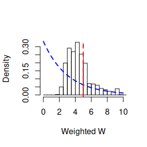

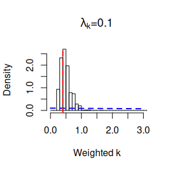

```r
plots_W[[1]]
plots_k[[1]]
```

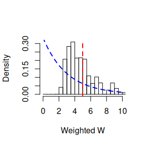

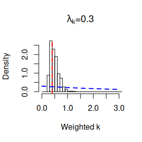

```r
plots_W[[2]]
plots_k[[2]]
```

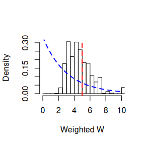

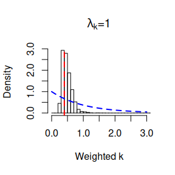

```r
plots_W[[3]]
plots_k[[3]]
```

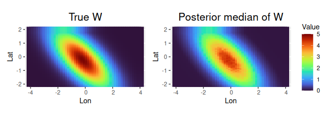

```r
out <- outList[[3]]
th <- theme(plot.title = element_text(size = 16, hjust = 0.5))
limits <- c(0,5)
W_post_medians <- sapply(1:L, function(l) calculate_summaries(out, what="W", locations=l)$median)
simData_sf$W_post_medians <- W_post_medians
plot_W_post_median <- ggplot(data=simData_sf) +
    geom_sf(aes(colour=W_post_medians),shape=15,size=5) +
    scale_colour_gradientn(colours=viridis::turbo(10),
                           name="Value",
                           na.value = "grey100",
                           limits = limits) +
    xlab("Lon") + ylab("Lat") + th +
  ggtitle("Posterior median of W")
pWtrue <- ggplot(data=simData_sf) +
  geom_sf(aes(colour=W),shape=15,size=5) +
  scale_colour_gradientn(colours=viridis::turbo(10),
                         name="Value",
                         na.value = "grey100",
                         limits = limits) + xlab("Lon") + ylab("Lat") + th +
  ggtitle("True W")
wrap_plots(list(pWtrue, plot_W_post_median), guides = 'collect', ncol = 2)
```

Note that we assumed a constant true parameter value $k=0.4$ for all locations, but obtained posterior samples for each location. To see how much the estimates for $k$ varied over space, we can look at the posterior median of each location:

```r
k_post_medians <- sapply(1:L, function(l) calculate_summaries(out, what="k", locations=l)$median)
summary(k_post_medians)
```

```
#>    Min. 1st Qu.  Median    Mean 3rd Qu.    Max.
#>   0.346   0.360   0.415   0.409   0.444   0.533
```